# Analyzing CIA Factbook Data Using SQLite and R

##### Case: Observations with NA values in the birth, death and migration_rate variable:

```r
dbExecute(conn, '
          UPDATE facts
            SET birth_rate = CASE
                                      WHEN birth_rate IS NULL
                                      THEN
                                        (SELECT AVG(birth_rate)
                                                          FROM facts
                                                          WHERE population BETWEEN 0 AND 1870981 AND
                                                                birth_rate IS NOT NULL AND
                                                                area BETWEEN 0 AND 10887)
                                      ELSE birth_rate
                                      END,
            death_rate = CASE
                                      WHEN death_rate IS NULL
                                      THEN
                                        (SELECT AVG(death_rate)
                                                          FROM facts
                                                          WHERE population BETWEEN 0 AND 1870981 AND
                                                                death_rate IS NOT NULL AND
                                                                area BETWEEN 0 AND 10887)
                                      ELSE death_rate
                                      END,
           migration_rate = CASE
                                      WHEN migration_rate IS NULL
                                      THEN
                                        (SELECT AVG(migration_rate)
                                                          FROM facts
                                                          WHERE population BETWEEN 0 AND 1870981 AND
                                                                migration_rate IS NOT NULL AND
                                                                area BETWEEN 0 AND 10887)
                                      ELSE migration_rate
                                      END
                    ')
```

```
## [1] 240
```

```r
# save cleaned table in a R dataframe
facts_cleaned <- dbGetQuery(conn, 'SELECT * FROM facts')

# count number of NA observations in cleaned dataframe
sum(is.na(facts_cleaned))
```

```
## [1] 0
```

```r
summary(facts_cleaned)
```

```
##        id             code               name                area
##  Min.   :  1.00   Length:240         Length:240         Min.   :       0
##  1st Qu.: 60.75   Class :character   Class :character   1st Qu.:    2186
##  Median :120.50   Mode  :character   Mode  :character   Median :   73580
##  Mean   :121.88                                         Mean   :  587459
##  3rd Qu.:180.25                                         3rd Qu.:  414643
##  Max.   :255.00                                         Max.   :17098242
##    area_land          area_water       population        population_growth
##  Min.   :       0   Min.   :     0   Min.   :0.000e+00   Min.   :0.000
##  1st Qu.:    2184   1st Qu.:     0   1st Qu.:3.161e+05   1st Qu.:0.430
##  Median :   72980   Median :   470   Median :5.220e+06   Median :1.020
##  Mean   :  568379   Mean   : 19080   Mean   :3.238e+07   Mean   :1.195
##  3rd Qu.:  400560   3rd Qu.:  6472   3rd Qu.:1.835e+07   3rd Qu.:1.847
##  Max.   :16377742   Max.   :891163   Max.   :1.367e+09   Max.   :4.020
##    birth_rate      death_rate     migration_rate     created_at
##  Min.   : 6.65   Min.   : 1.530   Min.   : 0.0000   Length:240
##  1st Qu.:11.97   1st Qu.: 5.978   1st Qu.: 0.4375   Class :character
##  Median :15.99   Median : 7.290   Median : 2.1400   Mode  :character
##  Mean   :19.11   Mean   : 7.756   Mean   : 3.6326
##  3rd Qu.:23.93   3rd Qu.: 9.363   3rd Qu.: 6.1047
##  Max.   :45.45   Max.   :14.890   Max.   :22.3900
##   updated_at
##  Length:240
##  Class :character
##  Mode  :character
##
##
##
```

```r
# check observation which still has one NA value
facts_cleaned %>%
    filter(is.na(area))
```

```
##  [1] id                code              name
##  [4] area              area_land         area_water
##  [7] population        population_growth birth_rate
## [10] death_rate        migration_rate    created_at
## [13] updated_at
## <0 rows> (or 0-length row.names)
```

Next, we will get to the main part where we will:

- look at summary statistics
- check correlations between the variables

# Main Part

Here I’ll calculate some summary statistics and check for any outlier countries. I’ll do this by writing a single query that returns the:

- minimum population
- maximum population
- minimum population growth
- maximum population growth

```r
dbGetQuery(conn, 'SELECT
          MIN(population), MAX(population), MIN(population_growth), MAX(population_growth)
          FROM facts
          ')
```

```
##   MIN(population) MAX(population) MIN(population_growth)
## 1               0      1367485388                      0
##   MAX(population_growth)
## 1                   4.02
```

```r
var(facts_cleaned$population)
```

```
## [1] 1.650137e+16
```

Looking at the results it seems that:

- there’s a country with a population of 0
- there’s a country with a population of 1367485388 or around 1.36 billion people!

Following I’ll include in the query above, the country name variable and a *WHERE* condition to select the cases we just asked for.

```r
dbGetQuery(conn, 'SELECT
          name, population, population_growth
          FROM facts
          WHERE population = (SELECT MIN(population) FROM facts) OR
                population = (SELECT MAX(population) FROM facts) OR
                population_growth = (SELECT MIN(population_growth) FROM facts) OR
                population_growth = (SELECT MAX(population_growth) FROM facts)
          ')
```

```
##                      name population population_growth
## 1                   China 1367485388          0.450000
## 2             South Sudan   12042910          4.020000
## 3 Holy See (Vatican City)        842          0.000000
## 4 Cocos (Keeling) Islands        596          0.000000
## 5               Greenland      57733          0.000000
## 6        Pitcairn Islands         48          0.000000
## 7              Antarctica          0          0.877619
```

Above we can identify the two cases with extreme low and high population value, these are, the 0 population case, which is Antartica as well as an entry of Chinas total population. Since Antartica is not a normal country with regular inhabitants and the only not permanent inhabitants are scientist , I’ll exclude it in a revised query, as well as save the result in a new object.

```r
facts_cleaned <- dbGetQuery(conn, "SELECT *
           FROM facts
           WHERE  (population != (SELECT MIN(population) FROM facts))
           ")

df_clean2 <- dbGetQuery(conn, "SELECT
                                   name, population, population_growth, birth_rate, death_rate
                                   FROM facts
                                   WHERE  (population != (SELECT MIN(population) FROM facts))
                                   ")

head(df_clean2)
```

```
##                  name population population_growth birth_rate death_rate
## 1         Afghanistan   32564342              2.32      38.57      13.89
## 2             Albania    3029278              0.30      12.92       6.58
## 3             Algeria   39542166              1.84      23.67       4.31
## 4             Andorra      85580              0.12       8.13       6.96
## 5              Angola   19625353              2.78      38.78      11.49
## 6 Antigua and Barbuda      92436              1.24      15.85       5.69
```

Now I’ll create histograms for each of the columns. Using just the non-outlier rows, generating histograms for the following columns:

- population
- population_growth
- birth_rate
- death_rate

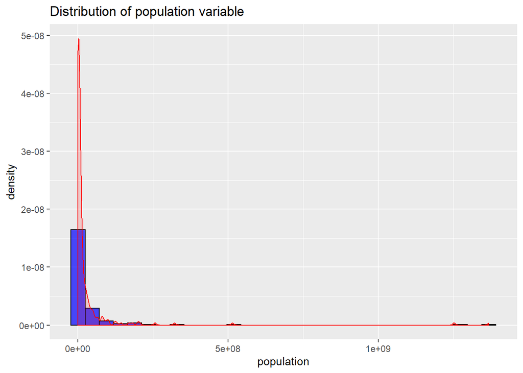

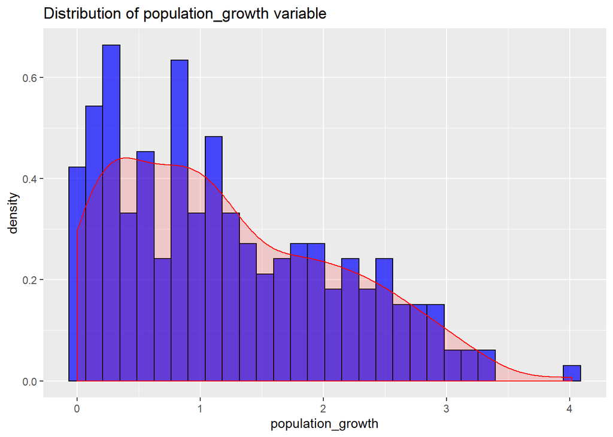

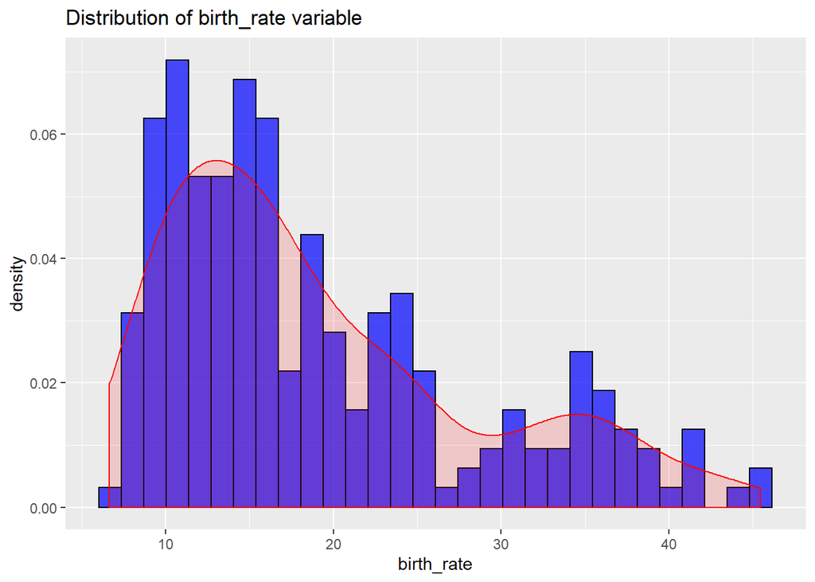

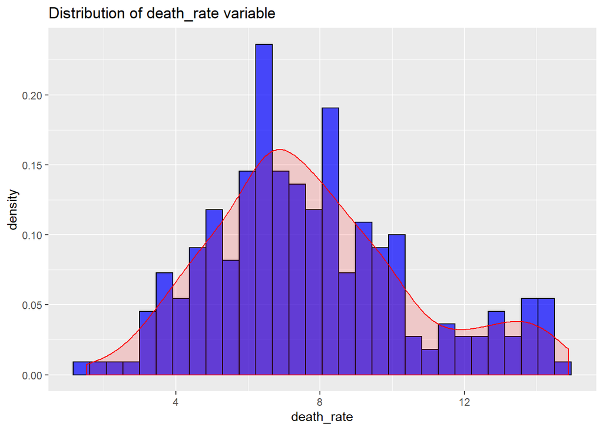

```r
# z = column vector
histog <- function (z) {
  ggplot(data = df_clean2) +
    aes_string(x = z) +
    geom_histogram(aes(y =..density..),
                 col="black",
                 fill="blue",
                 alpha= 0.7) +
    geom_density(col=2,
                 fill = "red",
                 alpha = 0.15) + # adding density line
    ggtitle(paste("Distribution of", z, "variable")) +
    geom_vline(aes(xintercept = mean(z)),col='red')
}


# Create the vector z:
z = names(df_clean2[,2:5])    # from the dataframe df2 selecting the columns: population

# Using map function from purrr package to run the function with the vector z:
map(z, histog)
```

It is visable that none of the variables have a normal, bell shaped distribution (so, not suitable for linear regression models), all of them, except the *death_rate* variable, are right skewed. Further we have extreme outliers in the population variable, which should be caused by countries like China and India. But since the population histogram is very skewed and difficult to read, I’ll redo it, scaling the x-axis properly as well as trying to use a different number of bins.

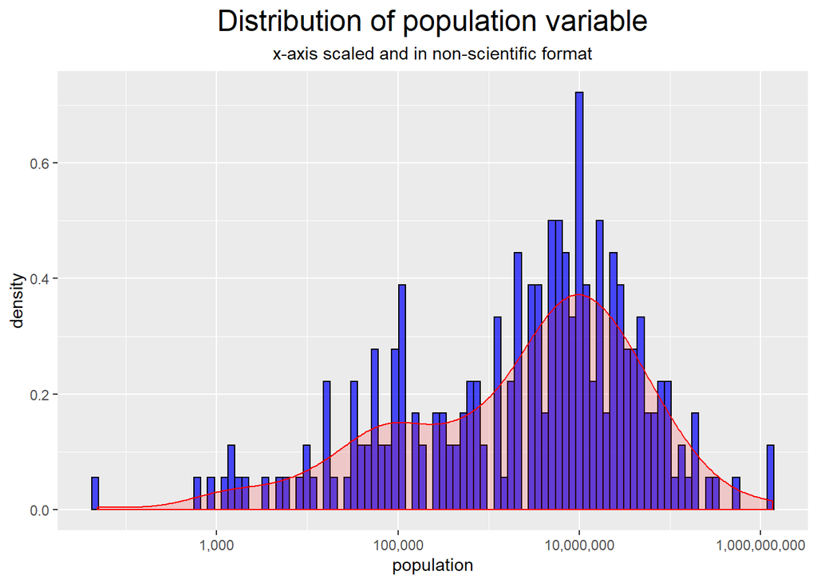

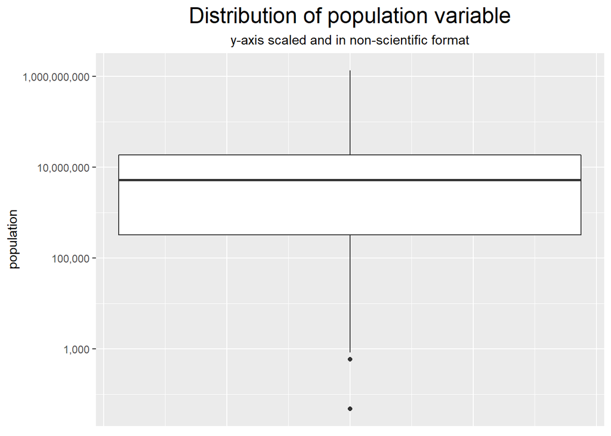

```r
# summary statistics of population variable
format(summary(df_clean2$population), scientific = FALSE)
```

```
##         Min.      1st Qu.       Median         Mean      3rd Qu.
## "        48" "    328258" "   5231422" "  32512449" "  18544404"
##         Max.
## "1367485388"
```

After adjusting the population histogram and adding a boxplot graphic, it is clear that around 50% of the countries found in the fact table have a population of more than 100,000 to a bit more than 10,000,000 inhabitants. Using R’s basic summary function shows that the median value is around *5.23 million* people.